# Tutorial 1

**Credits**: Andrea Galassi, Federico Ruggeri, Eleonora Mancini, Paolo Torroni

**Keywords**: Data loading, Feature Extraction, Machine Learning, Text Classification, Sentiment Analysis

# Contact

For any doubt, question, issue or help, you can always contact us at the following email addresses:

Teaching Assistants:

- Federico Ruggeri -> federico.ruggeri6@unibo.it
- Eleonora Mancini -> e.mancini@unibo.it

Professor:

- Paolo Torroni -> p.torroni@unibo.it

## Important

**Make sure** to put all of us in cc when contacting us via mail!

## PART I ($\sim$10 mins)

- How to **download** a dataset.
- How to **inspect** a dataset.

## PART II ($\sim$20 mins)

- How to perform basic **text pre-processing** to identify input features.

## PART III ($\sim$20 mins)

- How to **train a classifier** on identified input features for sentiment classification.
- How to **evaluate** model performance and **inspect** its predictions.

## Task

We consider the task of **document classification**.

Specifically, we consider document **sentiment analysis** on movie reviews.

## Preliminaries

# 1. Downloading the dataset

We download the IMDB movie reviews dataset.

```python
url = "http://ai.stanford.edu/~amaas/data/sentiment/aclImdb_v1.tar.gz"
dataset_name = "aclImdb"

print(f"Current work directory: {Path.cwd()}")
dataset_folder = Path.cwd().joinpath("Datasets")
```

```
Current work directory: /home/fruggeri/Downloads/tutorial-1/tutorial-1
```

```python
if not dataset_folder.exists():
    dataset_folder.mkdir(parents=True)

dataset_tar_path = dataset_folder.joinpath("Movies.tar.gz")
dataset_path = dataset_folder.joinpath(dataset_name)

if not dataset_tar_path.exists():
    download_dataset(dataset_tar_path, url)

if not dataset_path.exists():
    extract_dataset(dataset_tar_path, dataset_folder)
```

Let's have a look at the files we have downloaded to understand the dataset structure.

```python
# an example
file_path = dataset_folder.joinpath(dataset_name,
                                    'train',
                                    'pos',
                                    "0_9.txt")

if file_path.is_file():
    # open the file
    with file_path.open(mode='r', encoding='utf-8') as text_file:
        text = text_file.read()
        print(text)
```

```
Bromwell High is a cartoon comedy. It ran at the same time as some other programs about school life, such as "Teachers". My 35 years in the teaching profession lead me to believe that Bromwell High's satire is much closer to reality than is "Teachers". The scramble to survive financially, the insigh…
```

## 1.2 Inspecting the dataset

We first have a look at the dataframe structure.

```python
print("Dataframe structure:")
print(df)
print()
```

```
Dataframe structure:
      file_id  score  sentiment  split  \
0        2612     10          1  train
1        6812      7          1  train
2        8186     10          1  train
3       12429      7          1  train
4         584      8          1  train
...       ...    ...        ...    ...
49995   10246      2          0   test
49996    6175      4          0   test
49997    5113      4          0   test
49998   10221      2          0   test
49999    8400      2          0   test

                                                    text
0      This is a film that was very well done. I had ...
1      This two-part TV mini-series isn't as good as ...
2      I love the Satan Pit!!! David Tennant is such ...
3      David Duchovny plays the lead role in this fil...
4      Excellent film dealing with the life of an old...
...                                                  ...
49995  I have yet to watch STARCRASH (1979) - that no...
49996  There are many distinct problems with the movi...
49997  Orson Welles' 1974 documentary "F for Fake" ex...
49998  I found the first bit of stop motion animation...
49999  I really wanted to like this film, especially ...

[50000 rows x 5 columns]
```

```python
print("Total rows %d" % (len(df)))
print()
```

```
Total rows 50000
```

```python
print("Distribution of scores: ")
print(df['score'].value_counts())
print()
```

```
Distribution of scores:
score
1     10122
10     9731
8      5859
4      5331
3      4961
7      4803
9      4607
2      4586
Name: count, dtype: int64
```

```python
print("Distribution of sentiment: ")
print(df['sentiment'].value_counts())
print()
```

```
Distribution of sentiment:
sentiment
1    25000
0    25000
Name: count, dtype: int64
```

```python
print("Distribution of splits: ")
print(df['split'].value_counts())
print()
```

```
Distribution of splits:
split
train    25000
test     25000
Name: count, dtype: int64
```

```python
print("Distribution of sentiments in split: ")
print(df.groupby(['split','sentiment']).size())
print()
```

```
Distribution of sentiments in split:
split  sentiment
test   0            12500
       1            12500
train  0            12500
       1            12500
dtype: int64
```

```python
print("Distribution of scores in split: ")
print(df.groupby(['split','score']).size())
print()
```

```
Distribution of scores in split:
split  score
test   1        5022
       2        2302
       3        2541
       4        2635
       7        2307
       8        2850
       9        2344
       10       4999
train  1        5100
       2        2284
       3        2420
       4        2696
       7        2496
       8        3009
       9        2263
       10       4732
dtype: int64
```

```python
print("Differences in score distribution in split: ")
print(df.groupby(['score','split',]).size())
print()
```

```
Differences in score distribution in split:
score  split
1      test     5022
       train    5100
2      test     2302
       train    2284
3      test     2541
       train    2420
4      test     2635
       train    2696
7      test     2307
       train    2496
8      test     2850
       train    3009
9      test     2344
       train    2263
10     test     4999
       train    4732
dtype: int64
```

```python
print("Differences among score classes in the splits: ")
print(df.groupby(['sentiment','score','split']).size())
print()
```

```
Differences among score classes in the splits:
sentiment  score  split
0          1      test     5022
                  train    5100
           2      test     2302
                  train    2284
           3      test     2541
                  train    2420
           4      test     2635
                  train    2696
1          7      test     2307
                  train    2496
           8      test     2850
                  train    3009
           9      test     2344
                  train    2263
           10     test     4999
                  train    4732
dtype: int64
```

### 1.2.1 Visualization

We first visualize sentiment class distribution.

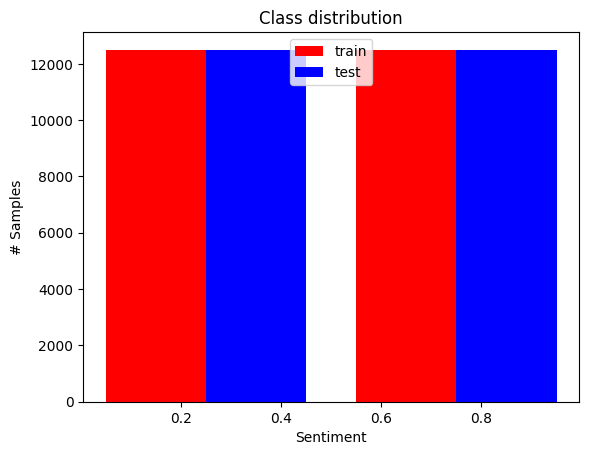

```python
plt.hist([train_labels,test_labels], bins=2, label=['train','test'],
         color=["red", "blue"], align="mid")
plt.legend(loc='upper center')
plt.title('Class distribution')
plt.xlabel('Sentiment')
plt.ylabel('# Samples')
plt.show()
```

Then we visualize sentiment scores.

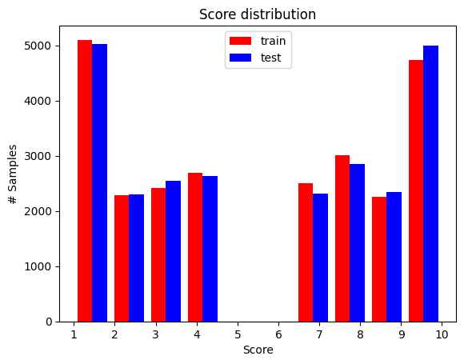

```python
plt.xticks(range(1,11))
plt.hist([train_scores,test_scores], bins=10, label=['train','test'], color=["red", "blue"], align="mid")
plt.legend(loc='upper center')
plt.title('Score distribution')
plt.xlabel('Score')
plt.ylabel('# Samples')

plt.show()
```

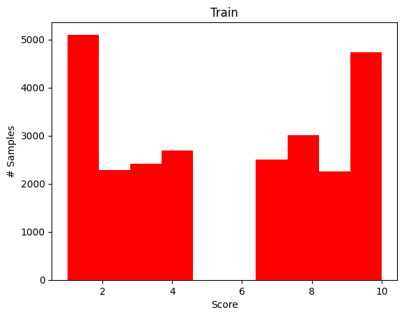

```python
plot1 = plt.figure(1)
plt.hist(train_scores, 10, color="red")
plt.xlabel('Score')
plt.ylabel('# Samples')
plt.title("Train")
plt.show()
```

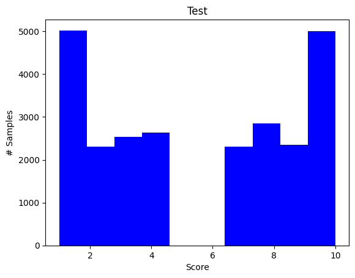

```python
plot2 = plt.figure(2)
plt.hist(test_scores, 10, color="blue")
plt.xlabel('Score')
plt.ylabel('# Samples')
plt.title("Test")
plt.show()
```

Lastly, we check text length distribution.

```python
import nltk
from nltk.tokenize import word_tokenize

# necessary for being able to tokenize
nltk.download('punkt_tab')
nltk.download('punkt')

train_texts = df[df.split == 'train'].text.values
test_texts = df[df.split == 'test'].text.values

train_lengths = [len(word_tokenize(text)) for text in tqdm(train_texts)]
test_lengths = [len(word_tokenize(text)) for text in tqdm(test_texts)]
```

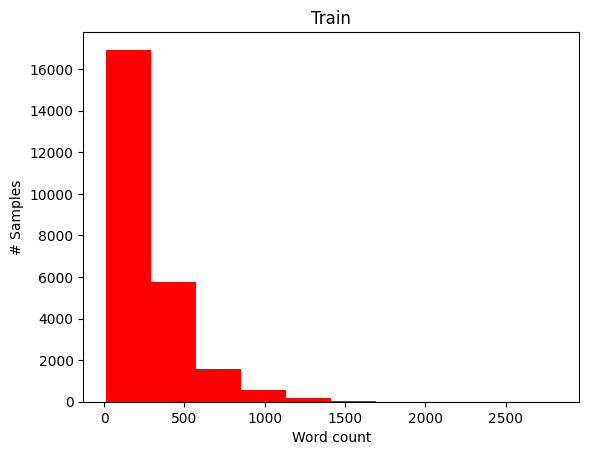

```python
plot1 = plt.figure(1)
plt.hist(train_lengths, color="red")
plt.xlabel('Word count')
plt.ylabel('# Samples')
plt.title("Train")
plt.show()
```

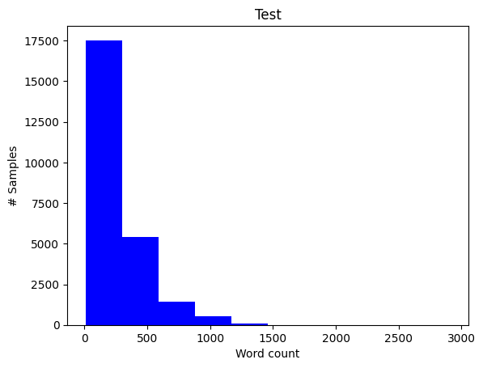

```python
plot2 = plt.figure(2)
plt.hist(test_lengths, 10, color="blue")
plt.xlabel('Word count')
plt.ylabel('# Samples')
plt.title("Test")
plt.show()
```

## 2. Feature Extraction

We are now ready to address the sentiment analysis task.

We consider the sentiment classification task for description purposes.

We first **determine** the inputs and outputs of our classifier.

Then, we define **how to encode** the inputs and outputs for the classifier.

### Inputs and Outputs

[figure not shown]

### Input features and Outputs

We will encode input text into a numerical format: **bag-of-words**.

[figure not shown]

Sentiment score prediction has the same schema where the *output label* is replaced by the sentiment score.

### 2.1 Bag-of-Words Encoding

The [scikit-learn](https://scikit-learn.org/stable/) library offers *TfidfVectorizer*, a class that performs both tokenization and the creation of the Bag-of-Words (BoW) representation of a corpus.

In particular, it computes tf-idf representation for each word token.

#### Homework 📖

The class has plenty of options: it can be used also to count n-grams, excluding stop-words, and cutting off most and/or less frequent terms.

```python
from sklearn.feature_extraction.text import  TfidfVectorizer

# select only the training sentences
df_train = df.loc[df['split'] == "train"]

train_texts = df_train.text.values

print("Processing corpus\n")
vectorizer =  TfidfVectorizer()

# tokenization and creation of Bag of Words representation
X_train = vectorizer.fit_transform(train_texts)

print("Shape of the matrix: (data points, features)")
print(X_train.shape)
print()

# targets for the training set
Y_train = df_train.sentiment.values
```

```
Processing corpus

Shape of the matrix: (data points, features)
(25000, 74849)
```

The vectorizer **fits** on the provided texts to create an internal vocabulary.

The vocabulary is used to create the BoW representation.

The vocabulary is a dictionary that associates to each word a corresponding column in the feature matrix.

#### Homework 📖

Do not try to print the whole vocabulary: it is quite large ;)

Still, **it is very important** to have a look at detected tokens!

Let's check the size of the built vocabulary.

```python
print("Size of vocabulary:")
print(len(vectorizer.vocabulary_))
print(type(vectorizer.vocabulary_))
```

```
Size of vocabulary:
74849
<class 'dict'>
```

Since the vocabulary is quite big, the BoW representation of input texts is a *sparse* matrix (see [scipy.sparse](https://docs.scipy.org/doc/scipy/reference/sparse.html) for more info).

Simply put, a sparse matrix is represented as a dictionary of non-zero entries, where the keys are the matrix coordinates.

```python
print(X_train)
```

```
<Compressed Sparse Row sparse matrix of dtype 'float64'
	with 3445861 stored elements and shape (25000, 74849)>
  Coords	Values
  (0, 66562)	0.07841025179793305
  (0, 34585)	0.05272303257841431
  (0, 24536)	0.1883061117018734
  (0, 66322)	0.02870043572108777
  (0, 72196)	0.1365815208874141
  (0, 71159)	0.0489545934872282
  (0, 72557)	0.05229637210728325
  (0, 19585)	0.1541633301351671
  (0, 29369)	0.10508759558008135
  (0, 30282)	0.09966086432176464
  (0, 43280)	0.13207546236130194
  (0, 55536)	0.1111532962748588
  (0, 72784)	0.0667786126552014
  (0, 34683)	0.07953764754262024
  (0, 33004)	0.053550822100956935
  (0, 51858)	0.09117289942188996
  (0, 3258)	0.09834692421366407
  (0, 30118)	0.03725209153785677
  (0, 6543)	0.05524580175559009
  (0, 71950)	0.11586658037926366
  (0, 25450)	0.06348246213664689
  (0, 34721)	0.06110193345988525
  (0, 54663)	0.21848853853223746
  (0, 11850)	0.17252077090435042
  (0, 67125)	0.07582365156555282
  :	:
  (24999, 67080)	0.11850844933165625
  (24999, 23699)	0.11106026291890769
  (24999, 19563)	0.07029332704633987
  (24999, 4128)	0.13200035093549906
  (24999, 59806)	0.11303353451694939
  (24999, 3703)	0.14757563525685075
  (24999, 27619)	0.11156898969150293
  (24999, 38350)	0.1608108400074491
  (24999, 21041)	0.13570215386330767
  (24999, 5266)	0.11520819411980732
  (24999, 24077)	0.13683146957746511
  (24999, 21162)	0.11086274857286962
  (24999, 44530)	0.13743426176977053
  (24999, 30548)	0.11171594303672726
  (24999, 51012)	0.13840674458578042
  (24999, 59270)	0.14108402553654767
  (24999, 41349)	0.13700246041292272
  (24999, 37930)	0.1414797114975839
  (24999, 46246)	0.15887963352396897
  (24999, 16050)	0.2197113842722638
  (24999, 69645)	0.16970559091322132
  (24999, 48052)	0.17009170355786893
  (24999, 4114)	0.24483950745169775
  (24999, 63371)	0.43676248037660004
  (24999, 63369)	0.24045264554551068
```

It is possible to get the dense representation of a feature matrix.

**Keep in mind** that the matrix will occupy a lot of memory.

```python
print(X_train.toarray())
```

```
[[0. 0. 0. ... 0. 0. 0.]
 [0. 0. 0. ... 0. 0. 0.]
 [0. 0. 0. ... 0. 0. 0.]
 ...
 [0. 0. 0. ... 0. 0. 0.]
 [0. 0. 0. ... 0. 0. 0.]
 [0. 0. 0. ... 0. 0. 0.]]
```

#### Homework 📖

Try taking a subset of the matrix and inspect its dense representation.

We use our fitted Vectorizer to transform test texts as well.

**Make sure** you invoke `vectorizer.transform()` and **not** `vectorizer.fit_transform()`.

```python
# select only the test sentences
df_test = df.loc[df['split'] == "test"]
test_texts = df_test.text.values

X_test = vectorizer.transform(test_texts)
Y_test = df_test.sentiment.values
```

**GOLDEN RULE: DO NOT EVER EVER EVER EVER MESS WITH THE TEST SET!!!!**

You **should never** add or remove rows/instances/data points from the test set.

You **should never** alter the ground-truth labels.

You **can** process it to transform, add, or remove columns/features.

You **can** modify the train set more freely.

But **keep your gross fingerprints** from the test set: it is untouchable, whatever its quality.

[figure not shown]

So far, we have encoded the text as it is.

We can perform additional pre-processing to 'normalize' the provided text.

### 2.2 Stemming

*''Stemming usually refers to a crude heuristic process that **chops off** the ends of words to reduce words to a common form.''*

(Introduction to Information Retrieval ~ C. D. Manning)

**Example**

*programmer*, *programs*, *programming* $\rightarrow$ *program*

```python
from nltk.stem import SnowballStemmer
from nltk.tokenize import (word_tokenize,
 sent_tokenize,
 WhitespaceTokenizer)

stemmer = SnowballStemmer("english")
tokenizer = WhitespaceTokenizer()
```

```python
def stem_text(text: str):
    words = [stemmer.stem(word) for word in tokenizer.tokenize(text)]
    return " ".join(words)

st_train_texts = [stem_text(text) for text in tqdm(train_texts)]
st_test_texts = [stem_text(text) for text in tqdm(test_texts)]
```

```python
print(train_texts[0][:100])
print()
print(st_train_texts[0][:100])
```

```
This is a film that was very well done. I had heard mixed reviews while it was in production and hav

this is a film that was veri well done. i had heard mix review while it was in product and have been
```

We encoded the pre-processed texts as before via the `TfidfVectorizer`.

```python
print("Processing corpus\n")
st_vectorizer =  TfidfVectorizer()
st_X_train = st_vectorizer.fit_transform(st_train_texts)
st_X_test = st_vectorizer.transform(st_test_texts)

print("Shape of the matrix: (data points, features)")
print(st_X_train.shape)
print()
```

```
Processing corpus

Shape of the matrix: (data points, features)
(25000, 70363)
```

### 2.3 Lemmatization

*''Lemmatization usually refers to use a vocabulary and morphological analysis of words to return the base or dictionary form of a word, known as **lemma**''*

(Introduction to Information Retrieval ~ C. D. Manning)

**Example**

*saw*, *seen*, *sees* $\rightarrow$ *see*

```python
from nltk.stem import WordNetLemmatizer
from nltk import pos_tag
from nltk.corpus import wordnet

nltk.download('omw-1.4')
nltk.download('wordnet')
nltk.download('averaged_perceptron_tagger')
nltk.download('averaged_perceptron_tagger_eng')

lemmatizer = WordNetLemmatizer()
```

```python
def get_wordnet_key(pos_tag):
    if pos_tag.startswith('J'):
        return wordnet.ADJ
    elif pos_tag.startswith('V'):
        return wordnet.VERB
    elif pos_tag.startswith('N'):
        return wordnet.NOUN
    elif pos_tag.startswith('R'):
        return wordnet.ADV
    else:
        return 'n'

def lem_text(text: str):
    tokens = tokenizer.tokenize(text)
    tagged = pos_tag(tokens)
    words = [lemmatizer.lemmatize(word, get_wordnet_key(tag))
             for word, tag in tagged]
    return " ".join(words)
```

```python
lem_train_texts = [lem_text(text)
                   for text in tqdm(train_texts,
                                    leave=True,
                                    position=0)]
lem_test_texts = [lem_text(text)
                  for text in tqdm(test_texts,
                                   leave=True,
                                   position=0)]
```

```python
print(train_texts[50][:100])
print()
print(lem_train_texts[50][:100])
```

```
Guys and Dolls has to be one of my favorite musical movies ever. It is a very fun movie to watch and

Guys and Dolls have to be one of my favorite musical movie ever. It be a very fun movie to watch and
```

We encoded the pre-processed texts as before via the `TfidfVectorizer`.

```python
print("Processing corpus\n")
lem_vectorizer =  TfidfVectorizer()
lem_X_train = lem_vectorizer.fit_transform(lem_train_texts)
lem_X_test = lem_vectorizer.transform(lem_test_texts)

print("Shape of the matrix: (data points, features)")
print(lem_X_train.shape)
print()
```

```
Processing corpus

Shape of the matrix: (data points, features)
(25000, 70649)
```

## 3. Training and Evaluating a Classifier

We are now ready to try out some standard machine learning classifiers.

**But** first, we introduce some baselines.

#### The importance of defining good baselines

Good baselines are always needed to consistently evaluate employed models.

When proposing a novel model, good baselines are recent state-of-the-art models.

When proposing a benchmark, good baselines are general-purpose off-the-shelf models.

### 3.1 Baselines

The majority baseline always predicts the majority class.

The random baseline makes uniform random predictions.

Their performances will tell us how much difficult this task is.

```python
from sklearn.dummy import DummyClassifier

majority_classifier = DummyClassifier(strategy="prior")
uniform_classifier = DummyClassifier(strategy="uniform")

majority_classifier.fit(X_train, Y_train)
uniform_classifier.fit(X_train, Y_train)

Y_pred_train_maj = majority_classifier.predict(X_train)
Y_pred_test_maj = majority_classifier.predict(X_test)
Y_pred_train_uni = uniform_classifier.predict(X_train)
Y_pred_test_uni = uniform_classifier.predict(X_test)
```

#### Homework 📖

Try out a random baseline that samples predictions according to label distribution.

We now evaluate model predictions via some metrics.

```python
from sklearn.metrics import classification_report

def evaluate_classification(y_true, y_pred):
    report = classification_report(y_true,
                                   y_pred,
                                   target_names=['neg', 'pos'])
    print(report)
```

```python
evaluate_classification(y_true=Y_train, y_pred=Y_pred_train_maj)
evaluate_classification(y_true=Y_test, y_pred=Y_pred_test_maj)
```

```
              precision    recall  f1-score   support

         neg       0.50      1.00      0.67     12500
         pos       0.00      0.00      0.00     12500

    accuracy                           0.50     25000
   macro avg       0.25      0.50      0.33     25000
weighted avg       0.25      0.50      0.33     25000

              precision    recall  f1-score   support

         neg       0.50      1.00      0.67     12500
         pos       0.00      0.00      0.00     12500

    accuracy                           0.50     25000
   macro avg       0.25      0.50      0.33     25000
weighted avg       0.25      0.50      0.33     25000
```

```python
evaluate_classification(y_true=Y_train, y_pred=Y_pred_train_uni)
evaluate_classification(y_true=Y_test, y_pred=Y_pred_test_uni)
```

```
              precision    recall  f1-score   support

         neg       0.50      0.50      0.50     12500
         pos       0.50      0.50      0.50     12500

    accuracy                           0.50     25000
   macro avg       0.50      0.50      0.50     25000
weighted avg       0.50      0.50      0.50     25000

              precision    recall  f1-score   support

         neg       0.50      0.51      0.50     12500
         pos       0.50      0.50      0.50     12500

    accuracy                           0.50     25000
   macro avg       0.50      0.50      0.50     25000
weighted avg       0.50      0.50      0.50     25000
```

#### 3.1.1 The importance of model evaluation

In most cases, accuracy is **not a very informative metric**.

Precision, recall, and F1 are more informative

F1 is generally a good indicator. In particular, macro F1 in case the test set in unbalanced.

Whether precision or recall are more important depends on the specific application, if the priority is to avoid false positives or false negatives.

Other metrics do exists (e.g., Area Under ROC Curve), always check the literature to find the most informative way to measure something!

#### Homework 📖

Try sampling an unbalanced test set and run model evaluation.

Do you see any differences in terms of metric values?

```
<sklearn.metrics._plot.precision_recall_curve.PrecisionRecallDisplay at 0x7c00e9f15110>
```

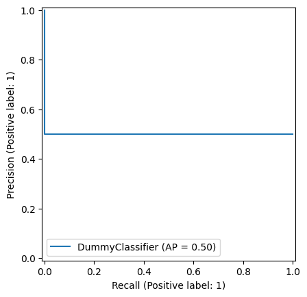

```python
PrecisionRecallDisplay.from_estimator(majority_classifier, X_test, Y_test)
```

```
<sklearn.metrics._plot.confusion_matrix.ConfusionMatrixDisplay at 0x7c01374ed890>
```

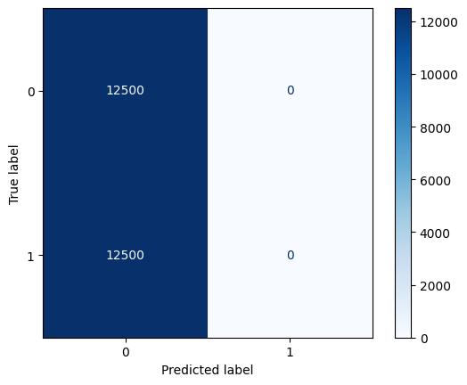

```python
ConfusionMatrixDisplay.from_estimator(majority_classifier, X_test, Y_test, normalize=None, cmap=plt.cm.Blues)
```

```
<sklearn.metrics._plot.confusion_matrix.ConfusionMatrixDisplay at 0x7c0136985b90>
```

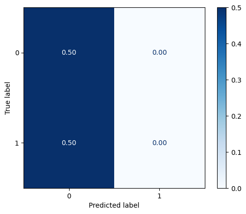

```python
ConfusionMatrixDisplay.from_estimator(majority_classifier, X_test, Y_test, normalize='all', cmap=plt.cm.Blues, values_format=".2f")
```

In most cases it is better to use the normalized version, especially with unbalanced distributions!

Looking at confusion tables row-wise gives information about recall, looking column-wise gives information about precision.

[figure not shown]

(wikipedia)

```
<sklearn.metrics._plot.precision_recall_curve.PrecisionRecallDisplay at 0x7c013776cdd0>
```

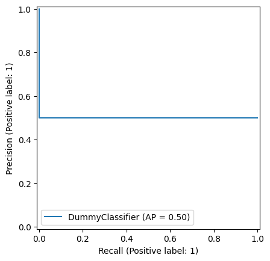

```python
PrecisionRecallDisplay.from_estimator(uniform_classifier, X_test, Y_test)
```

```
<sklearn.metrics._plot.confusion_matrix.ConfusionMatrixDisplay at 0x7c01378c6f50>
```

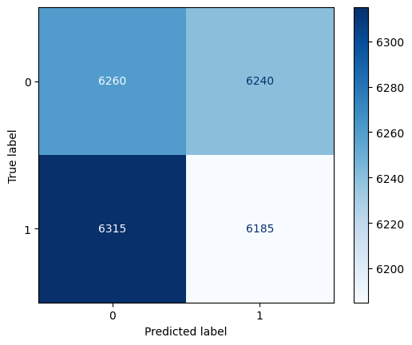

```python
ConfusionMatrixDisplay.from_estimator(uniform_classifier, X_test,
                                      Y_test, normalize=None, cmap=plt.cm.Blues)
```

```
<sklearn.metrics._plot.confusion_matrix.ConfusionMatrixDisplay at 0x7c00e8901610>
```

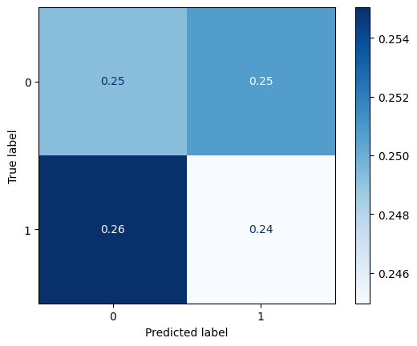

```python
ConfusionMatrixDisplay.from_estimator(uniform_classifier, X_test, Y_test,
                                      normalize='all', cmap=plt.cm.Blues,
                                      values_format=".2f")
```

### 3.2 Bayes Classifier

Let's try out our first classifier: A Naive Bayes Classifier (NB).

```python
from sklearn.naive_bayes import MultinomialNB

nb_classifier = MultinomialNB()

nb_classifier.fit(X_train, Y_train)

Y_pred_train_nb = nb_classifier.predict(X_train)
Y_pred_test_nb = nb_classifier.predict(X_test)
```

```python
evaluate_classification(y_true=Y_train, y_pred=Y_pred_train_nb)
evaluate_classification(y_true=Y_test, y_pred=Y_pred_test_nb)
```

```
              precision    recall  f1-score   support

         neg       0.89      0.93      0.91     12500
         pos       0.93      0.89      0.91     12500

    accuracy                           0.91     25000
   macro avg       0.91      0.91      0.91     25000
weighted avg       0.91      0.91      0.91     25000

              precision    recall  f1-score   support

         neg       0.79      0.89      0.84     12500
         pos       0.87      0.77      0.82     12500

    accuracy                           0.83     25000
   macro avg       0.83      0.83      0.83     25000
weighted avg       0.83      0.83      0.83     25000
```

```
<sklearn.metrics._plot.precision_recall_curve.PrecisionRecallDisplay at 0x7c00e6e39a50>
```

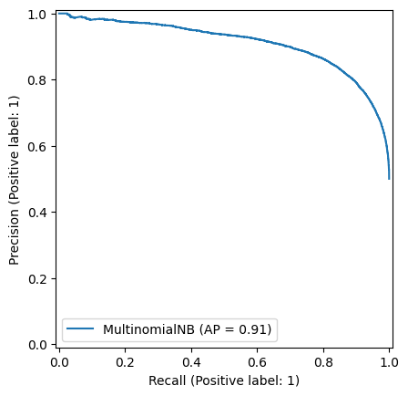

```python
PrecisionRecallDisplay.from_estimator(nb_classifier, X_test, Y_test)
```

```
<sklearn.metrics._plot.confusion_matrix.ConfusionMatrixDisplay at 0x7c00e9436290>
```

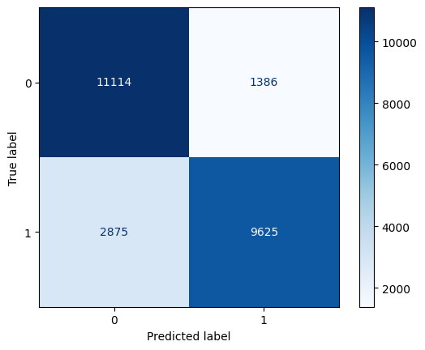

```python
ConfusionMatrixDisplay.from_estimator(nb_classifier, X_test,
                                      Y_test, cmap=plt.cm.Blues)
```

```
<sklearn.metrics._plot.confusion_matrix.ConfusionMatrixDisplay at 0x7c00e7804a10>
```

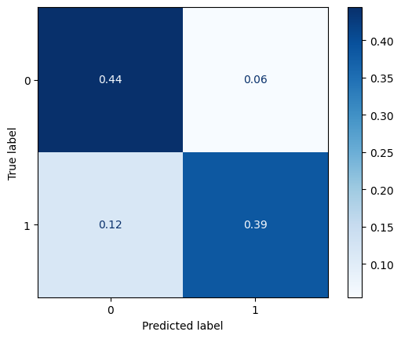

```python
ConfusionMatrixDisplay.from_estimator(nb_classifier, X_test, Y_test,
                                      normalize='all', cmap=plt.cm.Blues,
                                      values_format=".2f")
```

### 3.3 SVC Classifier

We consider another classifier: a Support Vector Machine (SVM).

```python
from sklearn.svm import LinearSVC

svc_classifier = LinearSVC()

svc_classifier.fit(X_train, Y_train)

Y_pred_train_svc = svc_classifier.predict(X_train)
Y_pred_test_svc = svc_classifier.predict(X_test)
```

```python
evaluate_classification(y_true=Y_train, y_pred=Y_pred_train_svc)
evaluate_classification(y_true=Y_test, y_pred=Y_pred_test_svc)
```

```
              precision    recall  f1-score   support

         neg       0.99      0.99      0.99     12500
         pos       0.99      0.99      0.99     12500

    accuracy                           0.99     25000
   macro avg       0.99      0.99      0.99     25000
weighted avg       0.99      0.99      0.99     25000

              precision    recall  f1-score   support

         neg       0.87      0.89      0.88     12500
         pos       0.89      0.87      0.88     12500

    accuracy                           0.88     25000
   macro avg       0.88      0.88      0.88     25000
weighted avg       0.88      0.88      0.88     25000
```

```
<sklearn.metrics._plot.precision_recall_curve.PrecisionRecallDisplay at 0x7c013688b4d0>
```

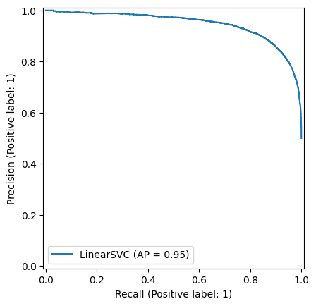

```python
PrecisionRecallDisplay.from_estimator(svc_classifier, X_test, Y_test)
```

```
<sklearn.metrics._plot.confusion_matrix.ConfusionMatrixDisplay at 0x7c00e7c9c290>
```

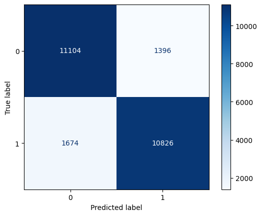

```python
ConfusionMatrixDisplay.from_estimator(svc_classifier, X_test,
                                      Y_test, cmap=plt.cm.Blues)
```

```
<sklearn.metrics._plot.confusion_matrix.ConfusionMatrixDisplay at 0x7c013679c910>
```

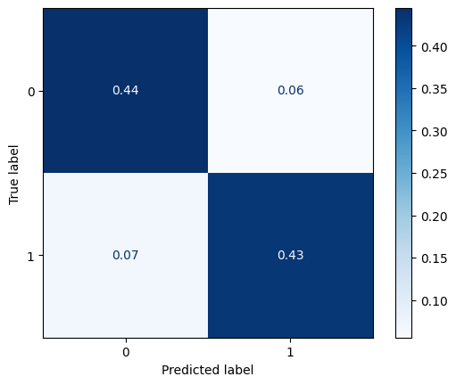

```python
ConfusionMatrixDisplay.from_estimator(svc_classifier, X_test, Y_test,
                                      normalize='all', cmap=plt.cm.Blues,
                                      values_format=".2f")
```

### 3.4 Error Analysis

Let's try to understand what kind of errors are done by the model.

We can look at specific cases of error.

```python
# confidence of the model
confidence = svc_classifier.decision_function(X_test)

fp_i = []
fn_i = []
fp_v = []
fn_v = []
fp_c = []
fn_c = []

for index, value in enumerate(Y_test):
    # false positives
    if value==0 and Y_pred_test_svc[index]==1:
        fp_i.append(index)
        fp_v.append(value)
        fp_c.append(confidence[index])
    # false negatives
    elif value==1 and Y_pred_test_svc[index]==0:
        fn_i.append(index)
        fn_v.append(value)
        fn_c.append(confidence[index])
```

Let's print some examples of FN and FP and the confidence in their classification

```python
print("FN")
print(test_texts[fn_i[1]])
print(fn_c[1])
```

```
FN
i see hundreds of student films- this is tops. james cox is a fantastic director- he moves the camera, tells the story and uses music in a way that is far advanced for his years. no wonder he got a feature from this film.<br /><br />
-0.37532633886611677
```

```python
print("FP")
print(test_texts[fp_i[5]])
print(fp_c[5])
```

```
FP
very straight - not happy with the movie.<br /><br />The main center of the movie is the story where the lady is the mother of all the snacks and all the things.<br /><br />If they can more explain that how this is happening and all the stuff then it was quite a fun and more rating for this movie.<b…
0.19836325970244123
```

We now check the sentences for which the classification error is bigger.

```python
max_fp = fp_c.index(max(fp_c))
print(test_texts[fp_i[max_fp]])
print(fp_c[max_fp])
```

```
This movie was pure genius. John Waters is brilliant. It is hilarious and I am not sick of it even after seeing it about 20 times since I bought it a few months ago. The acting is great, although Ricki Lake could have been better. And Johnny Depp is magnificent. He is such a beautiful man and a very…
2.070317237785626
```

```python
# for false negatives the confidence is negative
max_fn = fn_c.index(min(fn_c))
print(test_texts[fp_i[max_fn]])
print(fn_c[max_fn])
```

```
Step Up is a fair dance film about some kids that get their big performance break. The film is average in every way with little more for the viewer. A jock fights external prejudices to become a dancer with an accomplished partner and a teach who sees something special. The acting was fine, but the …
-1.9518688641072388
```

Let's now consider the stemmed and lemmatized versions of our input features.

```python
svc_classifier_st = LinearSVC()

svc_classifier_st.fit(st_X_train, Y_train)

Y_pred_train_svc_st = svc_classifier_st.predict(st_X_train)
Y_pred_test_svc_st = svc_classifier_st.predict(st_X_test)
```

```python
evaluate_classification(y_true=Y_train, y_pred=Y_pred_train_svc_st)
evaluate_classification(y_true=Y_test, y_pred=Y_pred_test_svc_st)
```

```
              precision    recall  f1-score   support

         neg       0.99      0.99      0.99     12500
         pos       0.99      0.99      0.99     12500

    accuracy                           0.99     25000
   macro avg       0.99      0.99      0.99     25000
weighted avg       0.99      0.99      0.99     25000

              precision    recall  f1-score   support

         neg       0.87      0.88      0.87     12500
         pos       0.88      0.86      0.87     12500

    accuracy                           0.87     25000
   macro avg       0.87      0.87      0.87     25000
weighted avg       0.87      0.87      0.87     25000
```

```python
svc_classifier_lem = LinearSVC()

svc_classifier_lem.fit(lem_X_train, Y_train)

Y_pred_train_svc_lem = svc_classifier_lem.predict(lem_X_train)
Y_pred_test_svc_lem = svc_classifier_lem.predict(lem_X_test)
```

```python
evaluate_classification(y_true=Y_train, y_pred=Y_pred_train_svc_lem)
evaluate_classification(y_true=Y_test, y_pred=Y_pred_test_svc_lem)
```

```
              precision    recall  f1-score   support

         neg       0.99      0.99      0.99     12500
         pos       0.99      0.99      0.99     12500

    accuracy                           0.99     25000
   macro avg       0.99      0.99      0.99     25000
weighted avg       0.99      0.99      0.99     25000

              precision    recall  f1-score   support

         neg       0.86      0.88      0.87     12500
         pos       0.88      0.86      0.87     12500

    accuracy                           0.87     25000
   macro avg       0.87      0.87      0.87     25000
weighted avg       0.87      0.87      0.87     25000
```

### 3.4.1 Comparisons

Let's organize our results in a Table to better compare models.

| Model | F1-macro |
| --- | --- |
| Random | .50 |
| Majority | .33 |
| NB | .83 |
| SVM | **.88** |
| SVM w/ Stem | .87 |
| SVM w/ Lem | .87 |

#### Homework

Try out the NB classifier with Stemmed and Lemmatized input features, respectively.

What do you observe?